# Biostatistical Computing, PHC 6068

Ridge regression, Lasso, and elastic net

Zhiguang Huo (Caleb)

Wednesday October 16th, 2019

# Outlines

- Ridge regression
- Lasso
- Elastic net

# linear regression model

- $Y = (Y_1, \ldots, Y_n)^\top \in \mathbb{R}^n$
- $X = (1_n, X_1, \ldots, X_p) \in \mathbb{R}^{n \times (p+1)}$
  - $1_n \in \mathbb{R}^n$,
  - $X_j \in \mathbb{R}^n$ with $1 \le j \le p$
- $\beta = (\beta_0, \beta_1, \ldots, \beta_p)^\top \in \mathbb{R}^{p+1}$
- $\varepsilon = (\varepsilon_1, \ldots, \varepsilon_n)^\top \in \mathbb{R}^n$

$$Y = X\beta + \varepsilon$$

# Solution to linear regression model

- least square estimator (LS):
  $$\hat{\beta} = \arg \min_\beta \frac{1}{2}\| Y - X\beta\|_2^2$$
  - $\|a\|_2 = \sqrt{a_1^2 + \ldots + a_p^2}$.
- Maximum likelihood estimator (MLE):
  $$\hat{\beta} = \arg \max_\beta L(\beta; X, Y)$$
- For linear regression model, LS estimator is the same as MLE
  $$\hat{\beta} = (X^\top X)^{-1} X^\top Y$$
  Assuming $X^\top X$ is invertable

# Problem with linear regression

- When $n>p$, number of subjects is larger than number of features (variables), linear model works fine.
- When $n<p$, $\hat{\beta} = (X^\top X)^{-1} X^\top Y$, $X^\top X \in \mathbb{R}^{p \times p}$ is singular. Thus we cannot estimate $\hat{\beta}$
  - Solution: apply PCA to $X$ and reduce to $X' \in \mathbb{R}^{n \times r}$, where $r<n$. (interpretation)
  - model selection: using backward selection, forward selection with BIC or AIC. (Searching space is large)
- When $n>p$, if two features are highly correlated, the resulting coefficients will have high variance and thus not stable.
  - Solution: PCA
  - Solution: use one one variable among all highly correlated variables as representative (using VIF to detect)

# Collinearity

```r
n <- 100
set.seed(32611)
x1 <- rnorm(n,3)
x2 <- rnorm(n,5)
x3 <- x2 + rnorm(n,sd=0.1)
cor(x2, x3)
```

```
## [1] 0.9957515
```

```r
x <- data.frame(x1,x2,x3)
y <- 2*x1 + 3*x2 + 4*x3 + rnorm(n, sd = 3)
xyData <- cbind(y,x)
lmFit <- lm(y~x1 + x2 + x3, data=xyData)
summary(lmFit)
```

```
##
## Call:
## lm(formula = y ~ x1 + x2 + x3, data = xyData)
##
## Residuals:
##      Min       1Q   Median       3Q      Max
## -10.2838  -1.7470   0.0118   1.8627   6.9231
##
## Coefficients:
##             Estimate Std. Error t value Pr(>|t|)
## (Intercept)  -1.5342     1.7695  -0.867   0.3881
## x1            2.2746     0.3116   7.299 8.39e-11 ***
## x2            5.2712     3.1574   1.669   0.0983 .
## x3            1.8343     3.1201   0.588   0.5580
## ---
## Signif. codes:  0 '***' 0.001 '**' 0.01 '*' 0.05 '.' 0.1 ' ' 1
##
## Residual standard error: 2.9 on 96 degrees of freedom
## Multiple R-squared:  0.8679, Adjusted R-squared:  0.8638
## F-statistic: 210.3 on 3 and 96 DF,  p-value: < 2.2e-16
```

# How to test collinearity

- Remove variable with VIF > 10

```r
library(car)
vif(lmFit)
```

```
##         x1         x2         x3
##   1.014903 118.852908 119.013351
```

```r
summary(lm(y~x1 + x2, data=xyData))
```

```
##
## Call:
## lm(formula = y ~ x1 + x2, data = xyData)
##
## Residuals:
##      Min       1Q   Median       3Q      Max
## -10.3139  -1.7410  -0.1042   1.8065   7.0280
##
## Coefficients:
##             Estimate Std. Error t value Pr(>|t|)
## (Intercept)  -1.5612     1.7629  -0.886    0.378
## x1            2.2572     0.3092   7.301 7.97e-11 ***
## x2            7.1196     0.2895  24.595  < 2e-16 ***
## ---
## Signif. codes:  0 '***' 0.001 '**' 0.01 '*' 0.05 '.' 0.1 ' ' 1
##
## Residual standard error: 2.891 on 97 degrees of freedom
## Multiple R-squared:  0.8674, Adjusted R-squared:  0.8647
## F-statistic: 317.4 on 2 and 97 DF,  p-value: < 2.2e-16
```

# To solve these problems

In the past several decades, regularization methods provide better solutions to this problem

- Ridge regression.
- lasso.
- Elastic net

# Ridge regression

$$\hat{\beta} = \arg \min_\beta \frac{1}{2}\| Y - X\beta\|_2^2 + \lambda \| \beta\|^2_2$$
- $\|a\|_2 = \sqrt{a_1^2 + \ldots + a_p^2}$.

- $\lambda \ge 0$ is a tuning parameter, controling the strength of the penalty term.
  - $\lambda =0$, Ridge regression reduces to linear regression $\hat{\beta}^{Ridge} = \hat{\beta}^{LS}$.
  - $\lambda = \infty$, we get $\hat{\beta}^{Ridge} = 0$
  - Given a positive $\lambda$, we both fit a linear model and shrink the coefficients.

# Ridge regression solution

$$\hat{\beta} = \arg \min_\beta \frac{1}{2}\| Y - X\beta\|_2^2 + \lambda \| \beta\|^2_2$$

- $\hat{\beta} = (X^\top X + \lambda I)^{-1} X^\top Y$
- As $\lambda$ increases, the bias increases and the variance decreases.

```r
library(MASS)
lm.ridge(y~x1 + x2 + x3, data=xyData, lambda = 10)
```

```
##                  x1        x2        x3
## 0.9529628 2.0535563 3.4643002 3.2671640
```

# Prostate cancer data

The data is from the book element of statistical learning

```r
library(ElemStatLearn)
str(prostate)
```

```
## 'data.frame':    97 obs. of  10 variables:
##  $ lcavol : num  -0.58 -0.994 -0.511 -1.204 0.751 ...
##  $ lweight: num  2.77 3.32 2.69 3.28 3.43 ...
##  $ age    : int  50 58 74 58 62 50 64 58 47 63 ...
##  $ lbph   : num  -1.39 -1.39 -1.39 -1.39 -1.39 ...
##  $ svi    : int  0 0 0 0 0 0 0 0 0 0 ...
##  $ lcp    : num  -1.39 -1.39 -1.39 -1.39 -1.39 ...
##  $ gleason: int  6 6 7 6 6 6 6 6 6 6 ...
##  $ pgg45  : int  0 0 20 0 0 0 0 0 0 0 ...
##  $ lpsa   : num  -0.431 -0.163 -0.163 -0.163 0.372 ...
##  $ train  : logi  TRUE TRUE TRUE TRUE TRUE TRUE ...
```

```r
prostate$train <- NULL
```

# Ridge regression Prostate cancer data example

```r
library(MASS)
lm_ridge <- lm.ridge(lpsa ~ ., data=prostate, lambda=0); lm_ridge
```

```
##                    lcavol      lweight          age         lbph
##  0.181560862  0.564341279  0.622019787 -0.021248185  0.096712523
##          svi          lcp      gleason        pgg45
##  0.761673403 -0.106050939  0.049227933  0.004457512
```

```r
lm(lpsa ~ ., data=prostate)
```

```
##
## Call:
## lm(formula = lpsa ~ ., data = prostate)
##
## Coefficients:
## (Intercept)       lcavol      lweight          age         lbph
##    0.181561     0.564341     0.622020    -0.021248     0.096713
##         svi          lcp      gleason        pgg45
##    0.761673    -0.106051     0.049228     0.004458
```

# Ridge regression Prostate cancer data example 2

```r
lm.ridge(lpsa ~ ., data=prostate, lambda=10)
```

```
##                    lcavol      lweight          age         lbph
## -0.023822581  0.470383515  0.595477805 -0.015328827  0.082534382
##          svi          lcp      gleason        pgg45
##  0.663639476 -0.022092251  0.066864682  0.003190709
```

```r
lm.ridge(lpsa ~ ., data=prostate, lambda=Inf)
```

```
##            lcavol  lweight      age     lbph      svi      lcp  gleason
## 2.478387 0.000000 0.000000 0.000000 0.000000 0.000000 0.000000 0.000000
##    pgg45
## 0.000000
```

# Summary for Ridge regression

- Ridge regression will stabilize the varaince of the coefficient estiamtes.
- Ridge regression will increase bias but decrease variance.
- Problem with Ridge regression: coefficient won’t be shrinked to exact 0, unless $\lambda = +\infty$.

# lasso

- The full name of Lasso is least absolute shrinkage and selection operator (Tibshirani, 1996)
- Lasso, the $l_1$ norm penalty will shrink some of the coefficients to exact zero.
  $$\hat{\beta}^{lasso} = \arg\min_{\beta \in \mathbb{R}^P} \frac{1}{2} \|y - X\beta\|_2^2 + \lambda \|\beta\|_1$$
- $\|\beta\|_1 = \sum_{j=1}^p |\beta_j|$ is called $l_1$ norm of $\beta$.
- $\lambda \ge 0$ is a tuning parameter, controling the strength of the penalty term.
  - $\lambda =0$, we have original linear regression.
  - $\lambda = \infty$, we get $\hat{\beta}^{lasso} = 0$
  - For $\lambda$, we both fit a linear model and shrink some coefficients to **exact zero**.

# lasso example (penalty form)

- lasso was implemented in R lars package.

```r
library(lars)
x <- as.matrix(prostate[,1:8])
y <- prostate[,9]
lassoFit <- lars(x, y) ## lar for least angle regression
coef(lassoFit, s=2, mode="lambda") ## get beta estimate when lambda = 2.
```

```
##    lcavol   lweight       age      lbph       svi       lcp   gleason
## 0.4506712 0.2910916 0.0000000 0.0000000 0.3475427 0.0000000 0.0000000
##     pgg45
## 0.0000000
```

```r
## Mode="lambda" uses s as the lasso regularization parameter for lambda
```

# lasso, the penalty form and the constraint form

- lasso regression equivalent forms.
  - in penalty form:
    $$\hat{\beta}^{lasso} = \arg\min_{\beta \in \mathbb{R}^P} \frac{1}{2} \|y - X\beta\|_2^2 + \lambda \|\beta\|_1$$
  - in constraint form:
    $$\hat{\beta}^{lasso} = \arg\min_{\beta \in \mathbb{R}^P} \frac{1}{2} \|y - X\beta\|_2^2, s.t, \|\beta\|_1 \le \mu$$

# lasso example (constraint form)

- lasso was implemented in R lars package.

```r
library(lars)
x <- as.matrix(prostate[,1:8])
y <- prostate[,9]
lassoFit <- lars(x, y) ## lar for least angle regression
coef(lassoFit, s=0.5, mode="fraction") ## get beta estimate when mu = 0.5*||beta_LS||_1
```

```
##       lcavol      lweight          age         lbph          svi
## 0.4746756454 0.4143707391 0.0000000000 0.0000000000 0.4499667198
##          lcp      gleason        pgg45
## 0.0000000000 0.0000000000 0.0001502949
```

```r
## If mode="fraction", then s should be a number between 0 and 1,
## and it refers to the ratio of the L1 norm of the coefficient vector,
## relative to the norm at the full LS solution.
```

# Re-visit AIC and BIC

- AIC and BIC will achieve feature selection.
  - $AIC = 2k - 2 \log ( {\hat{L}} )$
  - $BIC = log(n)k - 2 \log ( {\hat{L}} )$
- equivalently:

$$\hat{\beta}^{IC} = \arg\min_{\beta \in \mathbb{R}^P} \frac{1}{2} \|y - X\beta\|_2^2 + \lambda \|\beta\|_0$$

- $\|\beta\|_0$ equals to $k$ where $k$ is number of non-zero entries of $\beta$.
- $\|y - X\beta\|_2^2$ is equivalent to the likelihood function for Gaussian error.

# visualize lasso path

- lasso solution (beta estimate is piecewise linear with respect to lambda)
  - $\hat{\beta}^{lasso} = \arg\min_{\beta \in \mathbb{R}^P} \frac{1}{2} \|y - X\beta\|_2^2, s.t, \|\beta\|_1 \le \mu$
  - When $\mu > \|\hat{\beta}^{LS}\|_1$, $\hat{\beta}^{lasso} = \hat{\beta}^{LS}$

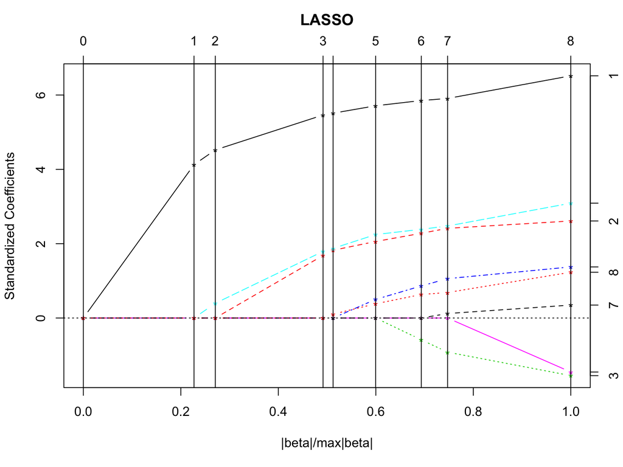

```r
plot(lassoFit)
```

- x-axis: $\frac{\|\beta\|_1}{\|\hat{\beta}^{LS}\|_1}$

# Intuition for lasso and Ridge regression

- lasso regression equivalent forms.
  - in penalty form:
    $$\hat{\beta}^{lasso} = \arg\min_{\beta \in \mathbb{R}^P} \frac{1}{2} \|y - X\beta\|_2^2 + \lambda \|\beta\|_1$$
  - in constraint form:
    $$\hat{\beta}^{lasso} = \arg\min_{\beta \in \mathbb{R}^P} \frac{1}{2} \|y - X\beta\|_2^2, s.t, \|\beta\|_1 \le \mu$$
- Ridge regression equivalent forms.
  - in penalty form:
    $$\hat{\beta}^{Ridge} = \arg\min_{\beta\in\mathbb{R}^p}
    \frac{1}{2} \|y - X\beta\|_2^2 + \lambda\|\beta\|_2^2$$
  - in constraint form:
    $$\hat{\beta}^{Ridge} = \arg\min_{\beta\in\mathbb{R}^p}
    \frac{1}{2} \|y - X\beta\|_2^2, s.t, \|\beta\|_2^2 \le \mu$$

# Intuition for lasso and Ridge regression

- Lasso: $\hat{\beta}^{lasso} = \arg\min_{\beta \in \mathbb{R}^P} \frac{1}{2} \|y - X\beta\|_2^2, s.t, \|\beta\|_1 \le \mu$
- Ridge: $\hat{\beta}^{Ridge} = \arg\min_{\beta\in\mathbb{R}^p} \frac{1}{2} \|y - X\beta\|_2^2, s.t, \|\beta\|_2^2 \le \mu$

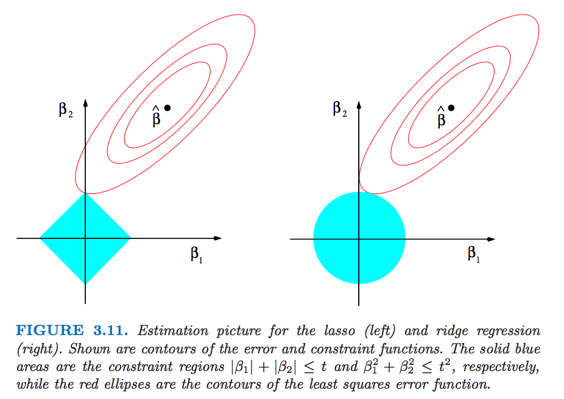

From book Element of Statistical Learning

# How to choose Tuning parameter

- cross validation, we leave this for future lectures.

# lasso path

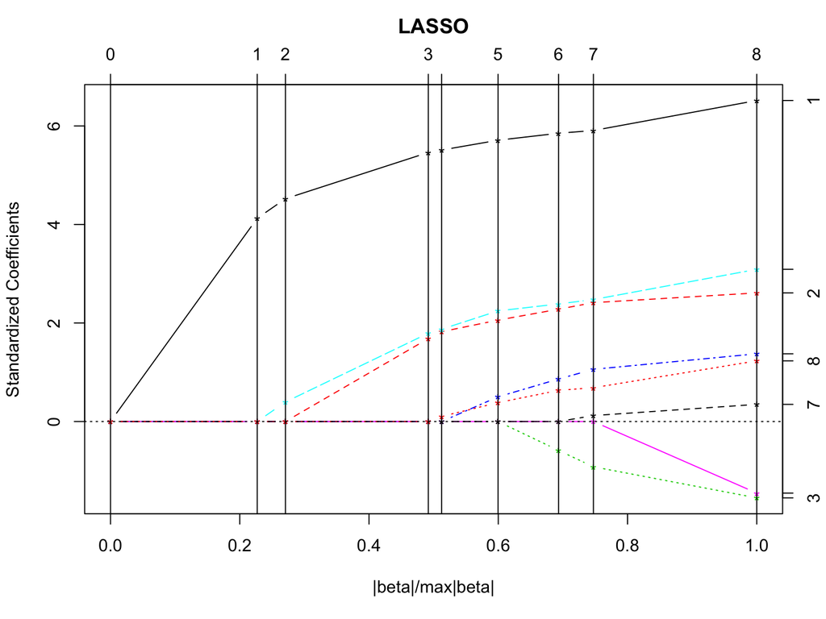

```r
plot(lassoFit)
```

- lasso solution is piecewise linear.
- The lars package only calculates the solution at the knots

# Elastic net

$$\hat{\beta}^{elastic} = \arg\min_{\beta \in \mathbb{R}^P} \frac{1}{2} \|y - X\beta\|_2^2 + \lambda_2 \|\beta\|_2 + \lambda_1 \|\beta\|_1$$

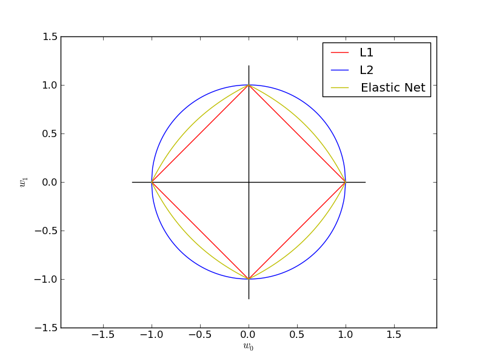

- In their paper, they claim elastic net has smaller Mean squared error.

# Group lasso

$$\min_{\beta=(\beta_{(1)},\dots,\beta_{(G)}) \in \mathbb{R}^p} \frac{1}{2} ||y-X\beta||_2^2 + \lambda \sum_{i=1}^G \sqrt{p_{(i)}} ||\beta_{(i)}||_2,$$

- Where $y \in \mathbb{R}^n$ is outcome and $X \in \mathbb{R}^{n\times p}$ is the design matrix.
- The design matrix can be partitioned in to $G$ groups $X = [X_{(1)}, \ldots, X_{(G)}]$ where $X_{(i)} \in \mathbb{R}^{n \times p_{(i)}}$.
- $\beta \in \mathbb{R}^p$ is the predictor and it is partitioned in to $G$ groups.

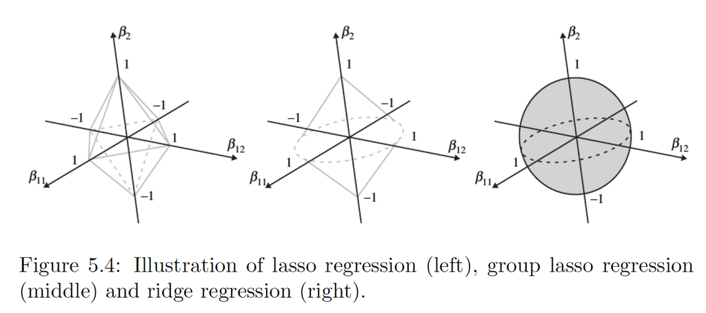

# Fused lasso

$$\min_{\beta \in \mathbb{R}^p} \frac{1}{2} || y - \beta ||_2^2 + \lambda \sum_{i=1}^{p-1} |\beta_i - \beta_{i+1}|$$

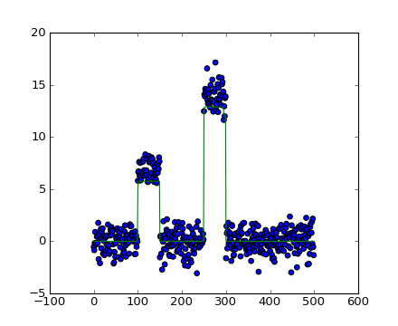

# Generalized lasso

Consider a general setting
$$\min_{\beta \in \mathbb{R}^p} f(\beta) + \lambda ||D\beta||_1$$
where $f: \mathbb{R}^n \rightarrow \mathbb{R}$ is a smooth convex function. $D \in \mathbb{R}^{m\times n}$ is a penalty matrix.